# Case Study: Text Classification

# With Caret

Remember the main function: train()

tidymodels is the tidy version of caret (collection of packages for modelling)

Let’s try 5-fold cross validation

```r
ctrl <- trainControl(method = "repeatedcv",
                     number = 5,
                     verboseIter = T)
```

Define now the tuning grid:

```r
nb_grid <-   expand.grid(usekernel = c(TRUE, FALSE),
                         laplace = c(0.2, 0.3, 0.4, 0.5),
                         adjust = c(0,0.5,1))
```

Take care: the input in caret should be a data frame, not a list

```r
X.train.bin = X.train.bin %>% as.matrix() %>% as.data.frame()
X.test.bin = X.test.bin %>% as.matrix() %>% as.data.frame()
```

Take care: the multinomial naive bayes is not implemented in caret

```r
nb_mod <- train(x = X.train.bin,
                y = y.train,
                method = "naive_bayes",
                trControl = ctrl,
                tuneGrid = nb_grid)
nb_pred <- predict(nb_mod, newdata = X.test.bin)

confusionMatrix(nb_pred,y.test)
```

```
## Confusion Matrix and Statistics
##
##           Reference
## Prediction ham spam
##       ham  959   19
##       spam   6  130
##
##                Accuracy : 0.9776
##                  95% CI : (0.967, 0.9854)
##     No Information Rate : 0.8662
##     P-Value [Acc > NIR] : <2e-16
##
##                   Kappa : 0.8994
##
##  Mcnemar's Test P-Value : 0.0164
##
##             Sensitivity : 0.9938
##             Specificity : 0.8725
##          Pos Pred Value : 0.9806
##          Neg Pred Value : 0.9559
##              Prevalence : 0.8662
##          Detection Rate : 0.8609
##    Detection Prevalence : 0.8779
##       Balanced Accuracy : 0.9331
##
##        'Positive' Class : ham
##
```

Visualize the tuning process:

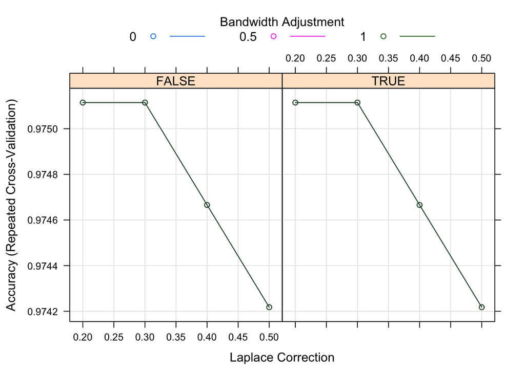

```r
plot(nb_mod)
```

Not too much gain here, but in practice a good tuning makes a difference!